# Deforestation

## Worldwide soy production over time

Streamgraph for soy production per continent:

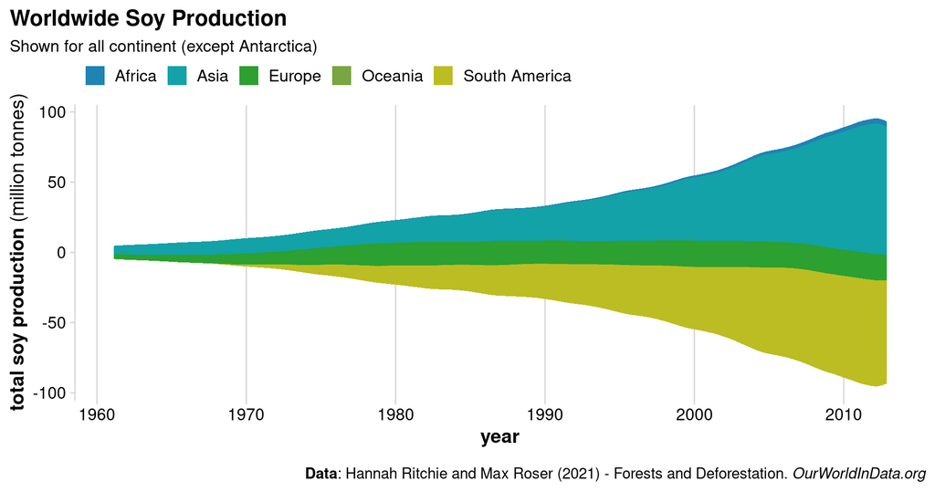

The global production of soy has increased rapidly over the last 60 years. Europe’s share in global production is stagnating and stable since around 1980. Growth in soy production mainly stems from production increases in Asia and South America.

## Interactive Streamgraph

[interactive chart not shown]

## Brazilian Forest Loss

To get a picture of total forest loss next to forest loss and its causes, it is useful to again regard the corresponding streamgraph:

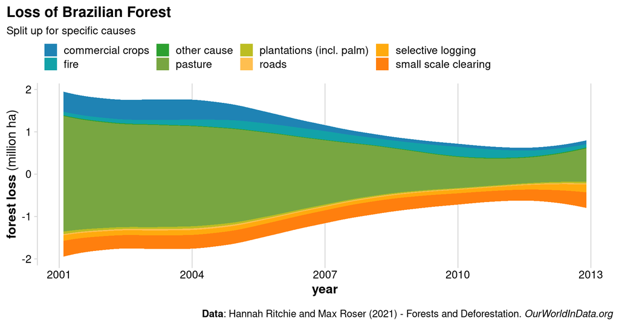

The graph shows that total forest loss between 2001 and 2004 is much higher than in more recent years. This corresponds to evolution of forest losses in other countries with increasing development. This trend however, could (temporarily) reverse in more recent years due to less regulatory restrictions. Pasture is the major cause of forest loss in Brazil. This is true over the whole time horizon. However, the share has been decreasing in recent years. Other causes, like fire, roads, or plantations including palm oil, play a much smaller - but also substantial - role.

## Share of global forest area per continent over time

Visualize change in change of global forest share over time:

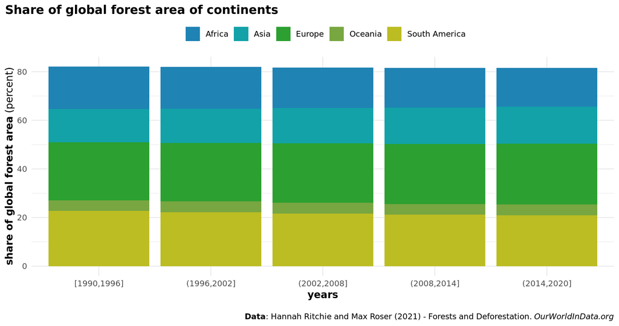

The share of each continents’ forest area of the world’s total forest area has not changed substantially over the last 30 years.

Full R code available at https://github.com/jgranna/tidytuesday